# Week 3 In-Class Lab

September 11, 2020

# 1 Goals

In this in-class lab, we will

- play around with different `ggplot` themes and color schemes
- learn about a few useful visualization packages that have different capabilities from `ggplot`

To guide you through this material, I will provide examples using the `gapminder` data that we worked with last week. Then you will work through similar problems using the `perceptions` data. Put briefly, the perceptions data deals with the perceptions of different words relating to probabilities and numbers. The raw data came from /r/samplesize responses to the following question: What [probability/number] would you assign to the phrase “[phrase]”? You can read more about the perceptions data at (https://github.com/zonination/perceptions).

# 2 Themes and Color Schemes

As I mentioned in the slides, it can become monotonous to look at 100+ plots with the same gridded gray `ggplot` background and the same default `ggplot` color scheme. A simple way to mix things up is to apply a different built-in `ggplot` theme. Pick your favorite or simply google “custom ggplot themes” for a plethora of options.

You can play around with the built-in ggplot themes or even build a custom theme if you’re feeling ambitious.

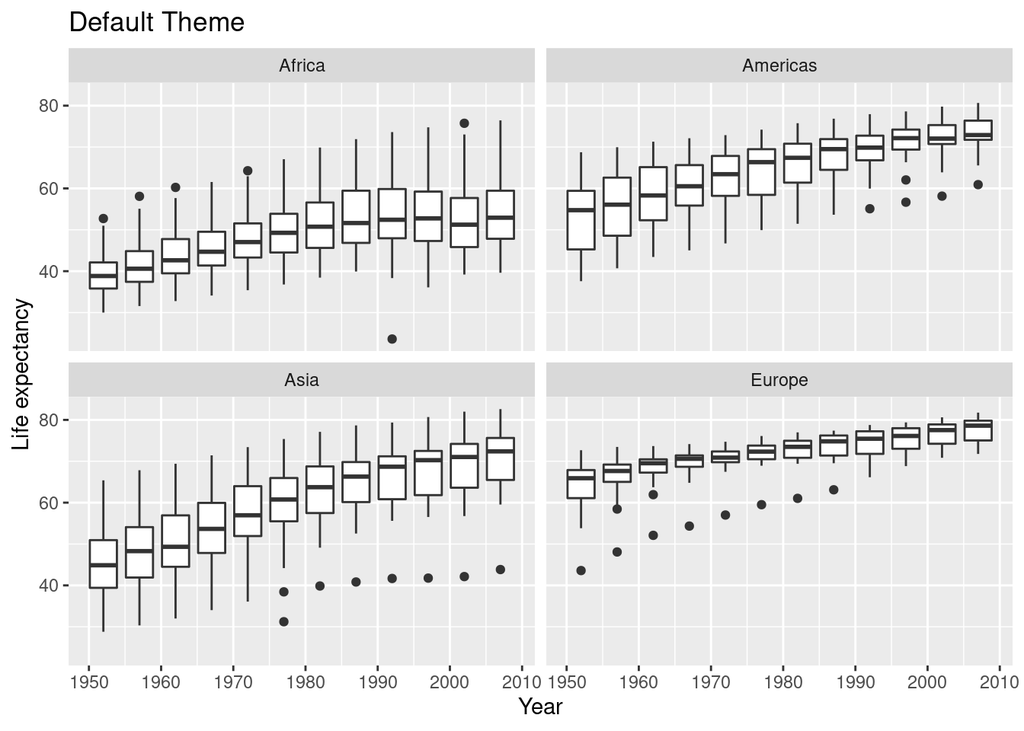

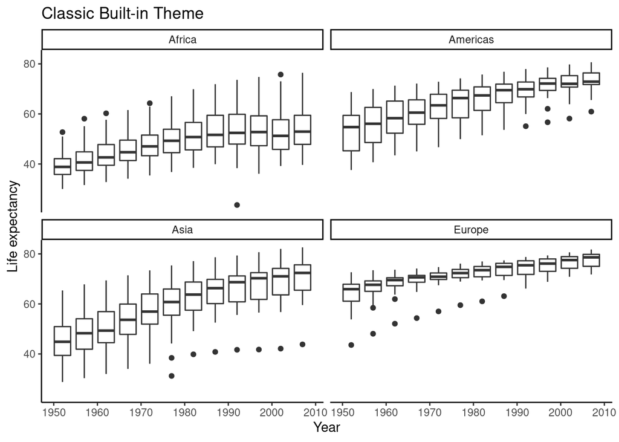

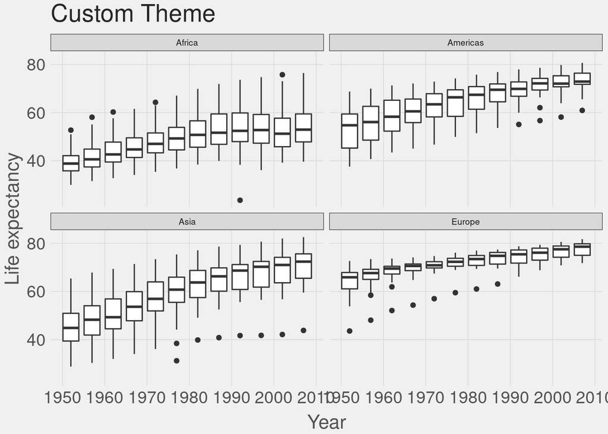

1. Compute the mean probability associated with each phrase in the `probly` data and plot the results in a bar graph. Add a built-in or custom ggplot theme to this plot. In your plot, make sure you can read the x-axis/phrase labels.

# 3 Color Schemes

Choosing an appropriate color scheme for your plots can drastically improve the readability of your plots. Sometimes, it is worthwhile to stray from the default colors in ggplot. The `viridis` package, in particular, has several nice continuous color schemes and can be easily applied to `ggplot` objects (see `scale_color_virids()` or `scale_fill_viridis()`). Aside from `viridis`, the package `RColorBrewer` has some nice color palettes, and if you’re incredibly ambitious, you can even create your own color palettes.

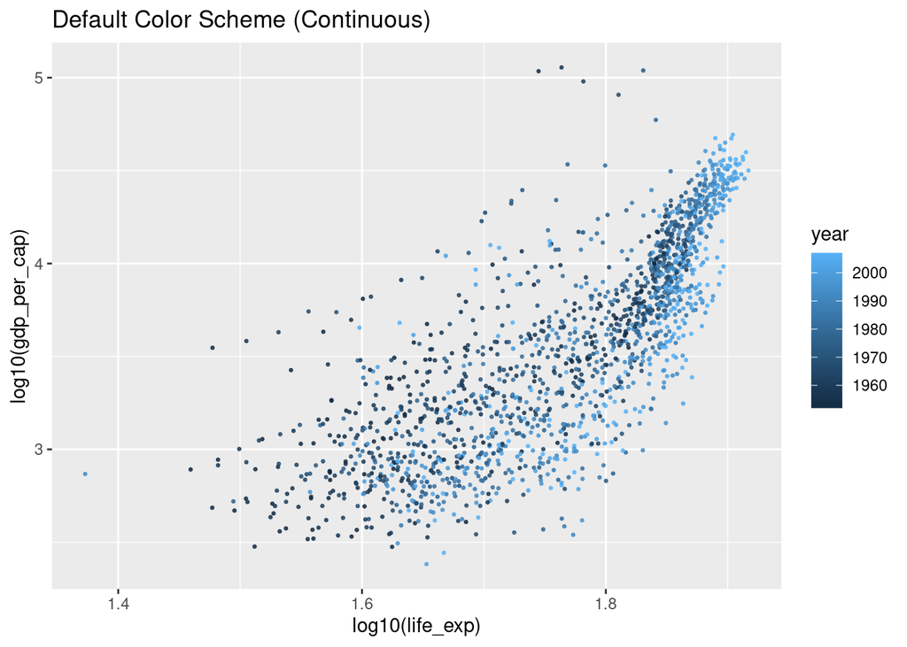

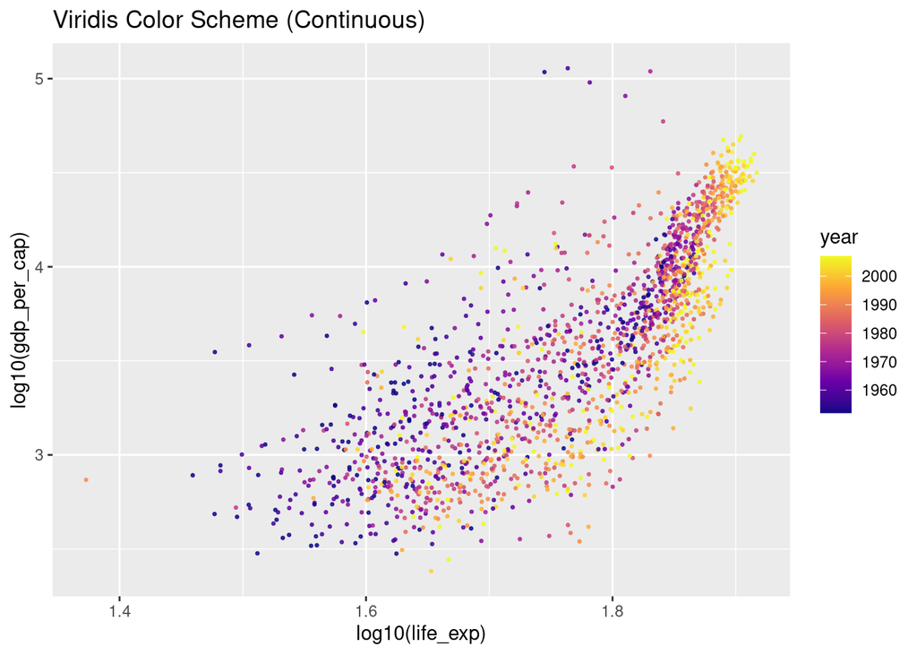

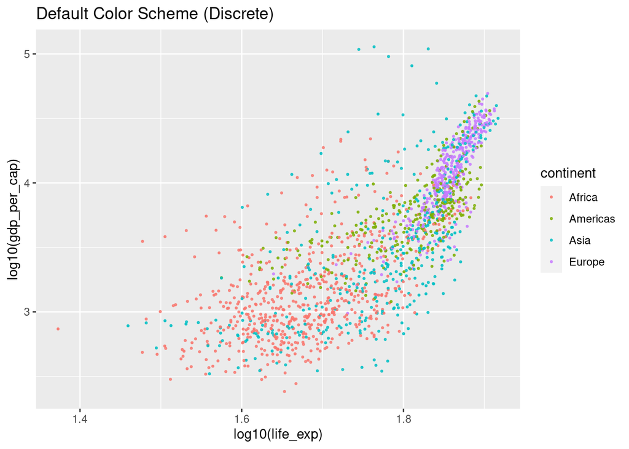

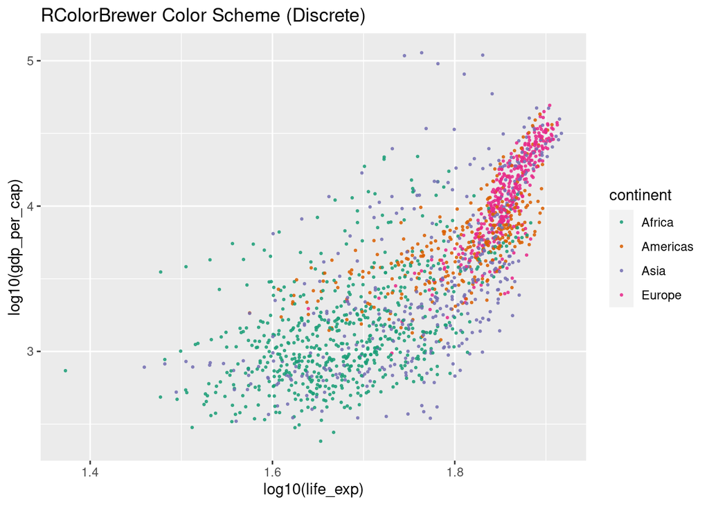

2. Using the `numberly` data, make a boxplot to visualize the distribution of assigned numbers corresponding to each phrase (i.e., there should be a boxplot for each phrase). Due to the highly skewed distributions, please take the $\log_{10}$-transform of the numeric data. Then, add an additional layer to the plot using `geom_jitter()` to explicitly plot the assigned numbers for each phrase. Finally, add an appropriate (non-default) color scheme to your plot.

# 4 Heatmaps

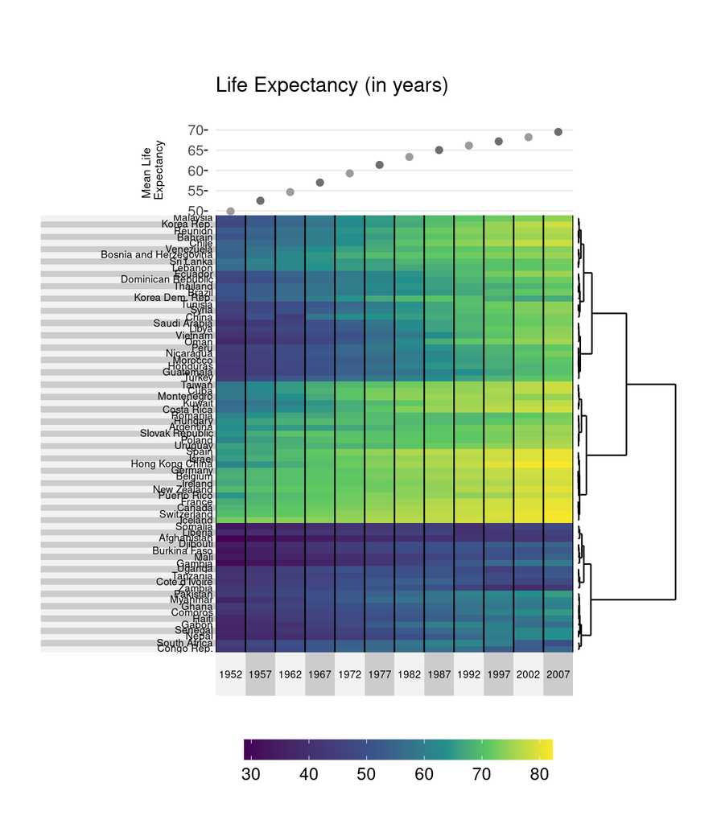

3. Use `superheat` to create a heatmap for the `probly` data, where the samples are on the x-axis, phrases on the y-axis, and probabilities represented by the heatmap values/colors. Cluster the samples using hierarchical clustering with complete linkage but don’t plot the resulting dendrogram. To the right of the heatmap, plot a bar graph with the average probabilities for each phrase.

# 5 Pair Plots

Last week, we looked at the relationship between life expectancy over time and gdp vs. life expectancy, but we did so separately. It may be informative to look at multiple pair-wise relationships in the data in a single plot. In the `GGally` package, the `ggpairs()` function allows us to plot a matrix of pair plots, showcasing many different pair-wise relationships in the dataset at the same time.

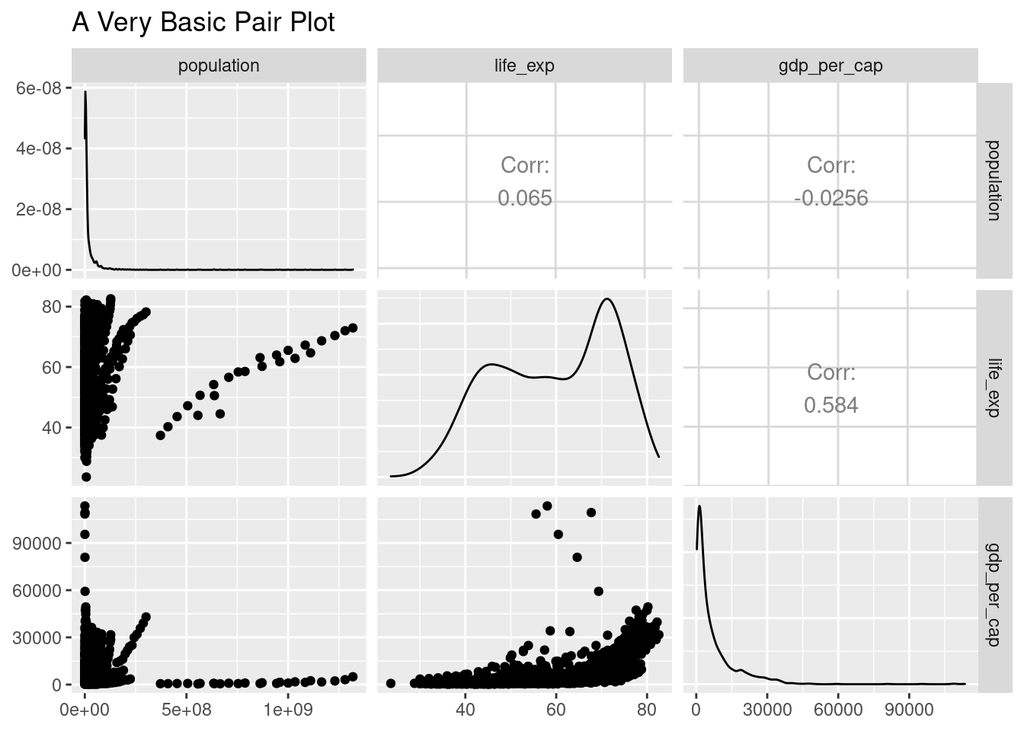

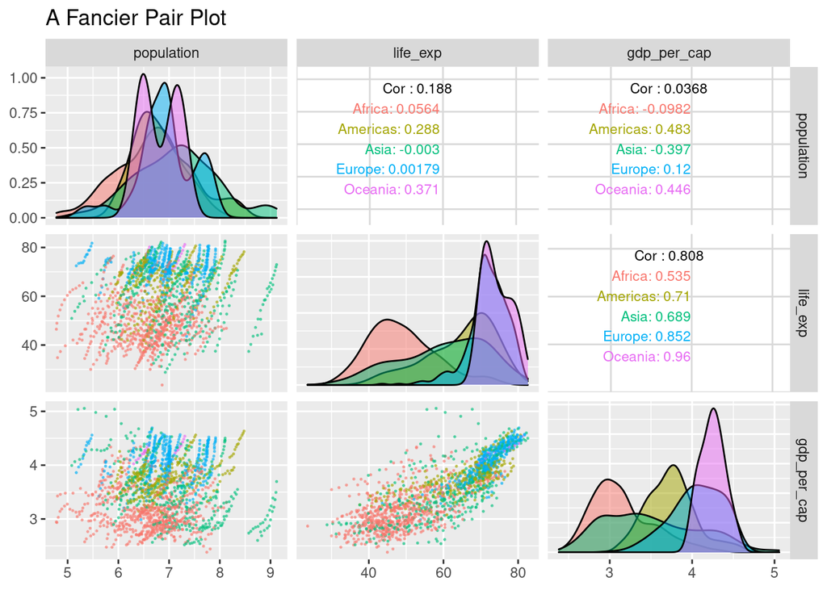

4. Going beyond pair-wise compairsons between continuous variables, `ggpairs` also allows for discrete variables in the pair plots. Create the same type of pair plot as above, but include the following four variables from `gapminder`: population, continent, life expectancy, and GDP per capita. Also, add a theme to your pair plot.

There are a lot of additional options that you can set in the `ggpairs()` function, so check out the help page for `ggpairs`. This help page is very informative, and you can do a lot with the `ggpairs` function.

# 6 Ridgeline Plots/Joyplots

The `ggridges` package provides an additional `geom` attribute called `geom_density_ridges` that can be added to `ggplot` objects. `geom_density_ridges` arranges multiple density plots in a staggered fashion.

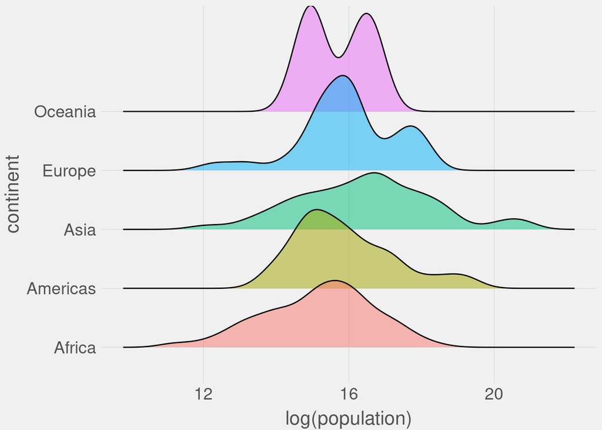

5. Use `geom_density_ridges` to make a nice visualization of the `numberly` data. Make sure to take care of skewness and add an appropriate (non-default) color scheme. Please also remove the legend.

# 7 Side-by-side Plots

Sometimes, it may be useful to organize multiple plots side-by-side. Two packages for doing so are `gridExtra::grid.arrange` and `ggpubr::ggarrange`.

6. One of the advantages of using `ggarrange` over `grid.arrange` is the ease of creating a common legend and subplot labels with `ggarrange`. Below, create two scatterplots using the `gapminder` data: the first scatterplot showing population vs. life expectancy and the second scatterplot showing gdp per capita vs life expectancy. Color the points in both scatterplots by continent and place these scatterplots side-by-side using `ggarrange`. Since both scatterplots have the same color legend, use a common legend and set the legend’s position to “below”. Also, set the `labels` argument to “AUTO”.
7. Unlike `ggarrange`, `grid.arrange` allows for very flexible plotting layouts. In addition to the two subplots that you created in exercise 6, create a third plot using `geom_bar` which shows the number of data points (i.e., countries) from each continent. Use `grid.arrange` to create a plot with the population vs life expectancy plot in the upper left quadrant, the GDP per capita vs life expectancy plot in the upper right quadrant, and the bar plot in the lower two quadrants. The end result should be similar to the plot shown in the gridExtra::grid.arrange slide from class.

# 8 Interactive Plots

Challenge Exercise: Come up with your own interactive visualization of the perception data. Be creative!